# **CSP2018** - Conference on Statistical Practice

Mar 5, 2017

Documentation of the [American Statistical Association’s](http://www.amstat.org/) [2018 Conference on Statistical Practice](http://www.amstat.org/meetings/csp/2018/), Feb 15-17, 2018 in Portland, OR.

# 1 Goals

Provide conference attendees with the opportunity to

- Learn new statistical methodologies and best practices in statistical analysis, design, consulting, and statistical programming.
- Further career development and strengthen relationships in the statistical community.

# 2 Themes

## 2.1 **CCCD** - Communication, Collaboration and Career Development

The objective for this theme is to help conference participants develop skills and perspectives that will improve their personal and professional effectiveness as statisticians and increase their organizational impact as managers, leaders, strategists, consultants or collaborators. Presentations will enable participants to return to their jobs with new ideas, techniques, and strategies for improving their ability to assume leadership roles, communicate effectively, forge productive professional relationships, and develop and advance their careers. Potential topics include the following:

- Organizational impact and influence
- Leadership and management
- Mentoring
- Effective communication
- Presenting statistical results to nonstatisticians
- Best practices in consulting and collaboration
- Career development and advancement
- Statistical ethics

## 2.2 **DMA** - Data Modeling and Analysis

The objective for this theme is to provide attendees with practical knowledge about modeling and analyzing data of various forms through the application of state-of-the-art statistical methods. Presentation methods should use illustrative data analysis examples reproducible across several statistical packages and may focus on a variety of data types from varied applied settings. Presentations will feature information relevant to a broad range of applied statisticians working in diverse settings. Potential topics include the following:

- Modeling
- Inference
- Prediction

## 2.3 **BDDS** - Big Data and Data Science

Big Data and Data Science are at the forefront of statistical practice and require a complex set of computing, statistical and communication skills. This conference theme aims to help practitioners working in these fields stay current with state-of-the-art methods for solving inference, prediction, decision making, classification, and pattern recognition problems from extremely large, unconventional, or complex data. Presentations pertaining to this theme will involve large data applications, overviews/surveys of methodological tools and algorithms for solving such applications and best practices for gathering, structuring, exploring, visualizing and analyzing large amounts of data. Potential topics include the following:

- Capturing, exploring, and visualizing large amounts of raw data
- Processing and cleaning raw data to produce analyzable data structures
- Scaling up statistical models for Big Data and Data Science applications
- Analysis techniques for high-throughput screening
- Text analytics and sentiment analysis
- Model validation and comparison approaches

## 2.4 **SPDV** - Software, Programming, and Data Visualization

The objective for this theme is to help attendees integrate new or existing software, statistically oriented programming languages (R, SAS, etc.), or general programming languages (Python, Java, etc.) into their current processes. Presentations will focus on the practical application of such technology for the statistician or data analyst. Potential topics include the following:

- Software and programming methods to obtain, clean, describe, or analyze data
- Methods for interactively sharing analysis results with other analysts or end users
- Visualization methods for communication and data discovery
- Statistical applications of general programming languages

# 3 Steering Committee

## 3.1 Charge

The Conference on Statistical Practice Steering Committee (CSPSC) is responsible for the program and organization of the annual Conference on Statistical Practice (CSP). The purpose of the conference is to bring together statistical practitioners (including data analysts, researchers and scientists) who engage in the application of statistics to solve real-world problems to provide them opportunities to learn about the latest statistical methodologies and best practices in statistical design, analysis, programming and consulting, and aid them in improving their abilities in consulting with and helping customers and organizations. In conjunction with ASA staff, the CSPSC will make policy decisions for the conference, set and evaluate conference goals in accordance with needs of the target audiences, select sites and dates, recommend registration and other fees, pursue sponsorships, and actively promote the conference.

## 3.2 Composition

The CSPSC will consist of up to fifteen members. Six of these are appointed by the President-Elects. Each President-Elect will appoint/reappoint three of these six members for two year terms. One of these three appointments is a vice-chair, who serves a one year term and then becomes chair for one year. The CSPSC Chair, in consultation with the remaining committee members, has the authority to appoint additional members (up to the maximum of 15 members) for 1-2 year terms in order to provide the diversity of statistical practice needed to round out the planning of the conference.

## 3.3 Members

Visit the ASA’s [Committee webpage](http://ww2.amstat.org/committees/commdetails.cfm?txtComm=CCNORG08) for more information on past and current members of the CSP Steering Committee.

|  | Name | Affiliation | Location | Appointment | Position | Expiration |
| --- | --- | --- | --- | --- | --- | --- |
| 1 | Adams, Jean V. | USGS Great Lakes Science Center | Antigo, WI | President-Elect | Chair | 2/28/2018 |
| 2 | Vance, Eric | University of Colorado Boulder | Boulder, CO | President-Elect | Vice-Chair | 2/28/2019 |
| 3 | Dohrmann, Sylvia Miller | Westat | Rockville, MD | President-Elect | Member | 2/28/2018 |
| 4 | Martinez, Wendy L. | Bureau of Labor Statistics | Fredericksburg, VA | President-Elect | Member | 2/28/2019 |
| 5 | Schweitzer, Laura G. | PriceWaterhouseCoopers | Gaithersburg, MD | President-Elect | Member | 2/28/2018 |
| 6 | Stephens, Eric B. | Vanderbilt University Medical Center | Nashville, TN | President-Elect | Member | 2/28/2018 |
| 7 | Corliss, David J. | Ford Motor Company | Plymouth, MI | Chair | Member | 2/28/2018 |
| 8 | Gao, Jinguo | Google Inc. | San Jose, CA | Chair | Member | 2/28/2019 |
| 9 | Ghement, Isabella | Ghement Statistical Consulting Company Ltd. | Richmond, BC | Chair | Member | 2/28/2018 |
| 10 | Jones, Edward R. | Texas A&amp;M Statistical Services | College Station, TX | Chair | Member | 2/28/2019 |

[output cut: 5 more lines]

[interactive chart not shown]

## 3.4 Subcommittees

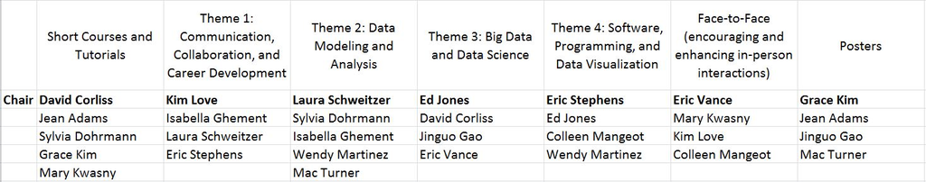

## 3.5 ASA Staff

- Amanda Conageski - Meetings Planner
- Donna LaLonde - Director of Strategic Initiatives and Outreach

# 4 Time Line

## 4.1 Visualization of Events and Tasks

Interactive time line of CSP2018 tasks and events.

- Hover your mouse over event to get more information.
- Pan or zoom to see other dates.

The color corresponds to the group responsible for each task.

- Steering Committee - bold black labels
- ASA - maroon labels
- Attendees, Presenters, etc. - blue labels

[interactive chart not shown]

## 4.2 Table of Events and Tasks

The interactive table below shows the data behind the calendar above.

- Search for any text in the table.
- Sort by column.
- Filter rows choosing a data range, a task category, or person responsible.

| Order | Start | End | Category | Who | Task |
| --- | --- | --- | --- | --- | --- |
| 1 |  | 2017-02-25 | General | Chair | Formation of subcommittees |
| 2 |  | 2017-02-25 | SC Meetings | Steering Committee | CSP2018 lunch meeting at CSP2017 |
| 3 |  | 2017-02-28 | Courses | Courses Subcommittee | Review call for short courses and tutorials |
| 4 |  | 2017-02-28 | General | Theme Subcommittees | Review themes |
| 5 |  | 2017-03-02 | Oral Sessions | Steering Committee | Final program tracks due from Committee |
| 6 |  | 2017-03-02 | General | Steering Committee | Invited Session criteria finalized by Committee |
| 7 | 2017-03-04 | 2017-03-18 | Courses | Steering Committee | Generate list of instructors to invite |
| 8 | 2017-03-04 | 2017-03-18 | Oral Sessions | Steering Committee | Generate list of presenters to invite |
| 9 |  | 2017-06-06 | General | Chair | Selection of CSP keynote speaker |
| 10 |  | 2017-03-30 | Courses | Steering Committee | Review call for short course and tutorial abstracts |

[output cut: 47 more lines]

# 5 Meeting Minutes & Action Items

## 5.1 Feb 25, 2017 (at CSP)

*[Minutes by Jean]*

12:30 - 2:00 PM, Hyatt Regency restaurant, Jacksonville

- Present: Grace Kim, Eric Vance (vice chair), Sylvia Dohrmann, David Corliss, Laura Schweitzer, Ed Jones, Kim Love, Mary Kwasny, Eric Stephens, Colleen Mangeot, Jean Adams (chair and minutes taker), Isabella Ghement, Donna LaLonde (ASA)
- Absent: Wendy Martinez, Jinguo Gao, Mac Turner, Amanda Conageski (ASA)

### 5.1.1 Paired Introductions

### 5.1.2 Goals of CSP

### 5.1.3 Approaching deadlines

- Mar 2 – Invited Session Criteria finalized by Committee
- Mar 2 – Final program tracks due from Committee
- Apr 5 – Steering Committee Conf. Call, 4 pm Eastern Time (1P, 2M, 3C)
- Apr 6 – Final Invitation List due from Committee – This deadline was pushed back (from Apr 4 to Apr 6) so that it occurs after our next conference call.
- Feb 15-17, 2018 – [CSP2018](https://ww2.amstat.org/meetings/csp/2018/) in Portland, OR

### 5.1.4 Invited vs. Open Call Sessions

- For CSP2017, we extended invitations to short course and tutorial instructors and Theme 3 Big Data and Data Science presenters. These invitations were sent by ASA and guaranteed non-competitive inclusion in the program if the invitee accepted. This was then followed up with an open call for additional instructors and presenters. For the other three themes, only an open call for abstracts was extended.
- For CSP2018, we agreed to repeat this combined invitation and open call approach and extend it to the other three themes as well. We believe the resulting increase in quality of courses/presentations at CSP2018 is worth the additional effort required by the Steering Committee and ASA to extend these invitations.
- **ACTION:** All Steering Committee members (regardless of subcommittee membership) will send suggested people to invite by **Mar 18** for
  - invited instructors to David and
  - for invited presenters to the appropriate theme chair:
    - Kim for Communication, Collaboration and Career Development,
    - Laura for Data Modeling and Analysis,
    - Ed for Big Data and Data Science, and
    - Eric Stephens for Software, Programming, and Data Visualization.
  - Each person should submit at least 1 suggestion for an invited instructor and at least 1 suggestion for an invited presenter (more are welcome). For each invitee, provide a name, email address, affiliation, and brief description of what they will bring to the CSP. The Short Course subcommittee and the 4 theme subcommittees will then review the suggestions, and share their recommendations for invitations with the entire steering committee **Mar 29**.
- **ACTION:** The Short Course and Tutorial subcommittee will review the call for short course abstracts and submit a revised document to the full committee by **Mar 23**. The full committee will have one week to comment on the revisions before the call is due to ASA, **Mar 30**. Suggestions to consider from our meeting include:
  - clarify that there are only a limited number of slots open
  - clearly state how the abstracts will be judged
  - ask the submitter what they want the audience to take away from their course/talk (the deliverable) and how they plan to make this happen
  - encourage instructors/presenters to engage their audience with interactive exercises.
- We discussed ways to determine whether an abstract submitter would give a quality course/presentation, e.g., ask for CV, ask for inclusion of example table or figure, ask for 30 second video abstract. Disadvantages to all of these is the additional work it requires by the committee members reviewing the abstracts and the management of the documents/links. Additional disadvantages of videos include (1) possible deterrent effect even on quality instructors/presenters and (2) possible concern about how those videos would be judged. **ACTION:** Kim and the Communication, Collaboration and Career Development subcommittee will further discuss and consider the optional use of video for abstracts submitted to the CCCD theme, and share their recommendation with full committee **Mar 29**. The call for oral presentation abstracts is not due until May 9.

### 5.1.5 Program tracks (theme descriptions) – due Mar 2

- **ACTION:** Steering Committee chairs work with your subcommittees to review the theme descriptions. Send the final product to Jean by noon Eastern time, **Mar 2**.

### 5.1.6 Subcommittee assignments (chair names in bold)

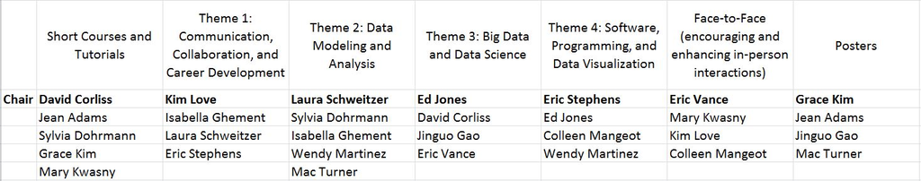

### 5.1.7 Miscellany

- To encourage attendance at Saturday morning talks, we suggest that lights in the breakfast area be turned off and on just before the talks begin.
- We very briefly discussed scheduling, e.g., the timing of the keynote address. Amanda tells me that ASA’s request for hotel bids included a schedule in it. So, to change the CSP schedule we will need to recommends changes (with justification) for review by ASA staff and potential consult with hotel.
- Possible idea for ASA to generate interest in CSP: create and share short video(s) of invited instructors.

## 5.2 Apr 5, 2017

4:00 pm Eastern (1:00 Pacific, 2:00 Mountain, 3:00 Central)  
Dial in: 1-800-250-3900  
Pin: 79173874#

Tentative agenda

- Attendees? Amanda Conageski (ASA) Colleen Mangeot, David Corliss, Donna LaLonde (ASA) Ed Jones, Eric Stephens, Eric Vance (vice chair), Grace Kim, Isabella Ghement, Jean Adams (chair and minutes taker), Jinguo Gao, Kim Love, Laura Schweitzer, Mac Turner, Mary Kwasny, Sylvia Dohrmann, Wendy Martinez
- Approaching deadlines
  - Apr 6 – Final Invitation Lists due from Committee
  - Next Meeting - week of May 1-5??
  - May 9 - Review call for oral presentation abstracts
- Invited Instructors
  - Short Courses and Tutorials - David
- Invited Presenters
  - Communication, Collaboration and Career Development - Kim
  - Data Modeling and Analysis - Laura
  - Big Data and Data Science - Ed
  - Software, Programming, and Data Visualization - Eric S.
- Call for Oral Presentation Abstracts
  - Use of videos - Kim, CCCD

## 5.3 May ??, 2017

## 5.4 May ??, 2017

## 5.5 Jun ??, 2017

## 5.6 Jul ??, 2017

## 5.7 Aug 31 - Sep 1 ??, 2017 (at JSM)

## 5.8 Sep ??, 2017

## 5.9 Nov ??, 2017

## 5.10 Jan ??, 2018